# Tugas Praktikum Pertemuan 1

Aurelia Fury

2026-08-26

## Tugas

1. Setiap kelompok memilih satu data time series dengan panjang ≥ 500 periode.
2. Data dibagi rata ke setiap anggota; minimal 100 observasi per orang.
3. Terapkan metode pemulusan yang sudah dipelajari (SMA, DMA, SES, DES, atau Holt-Winters) pada bagian data masing-masing
4. Bandingkan kinerja metode dan tentukan metode terbaik untuk data tersebut menggunakan metrik akurasi (mis. SSE/MSE/RMSE/MAPE), lalu jelaskan alasannya secara singkat.

## Library/Packages

```r
#install.packages("forecast")
#install.packages("graphics")
#install.packages("TTR")
#install.packages("TSA")
```

```r
library("forecast")
library("graphics")
library("TTR")
library("TSA")
library("ggplot2")
```

## Impor Data

Data yang digunakan adalah data **ISPU (Indeks Standar Pencemar Udara)** harian stasiun DKI1 (Bunderan HI), dengan variabel yang diramalkan adalah **PM10**. Data terdiri atas 112 observasi harian (8 September 2020 - 28 Desember 2020).

```r
library(rio)
data <- import("https://raw.githubusercontent.com/aureliafury/mpdw/refs/heads/main/Pertemuan%201/ispu_anggota_1.csv")

# menampilkan 5 data pertama
head(data)
```

```
##      tanggal            stasiun pm25 pm10 so2 co o3 no2 max critical categori
## 1 2020-09-08 DKI1 (Bunderan HI)   NA   58  22  5 47  12  81     PM25   SEDANG
## 2 2020-09-09 DKI1 (Bunderan HI)   NA   56  22  4 39   9  80     PM25   SEDANG
## 3 2020-09-10 DKI1 (Bunderan HI)   NA   56  18  6 78  13  80     PM25   SEDANG
## 4 2020-09-11 DKI1 (Bunderan HI)   NA   68  18  7 70  22  97     PM25   SEDANG
## 5 2020-09-12 DKI1 (Bunderan HI)   NA   59  18  7 99  18  99       O3   SEDANG
## 6 2020-09-13 DKI1 (Bunderan HI)   NA   60  18  7 86  11  86       O3   SEDANG
```

## Eksplorasi Data

`View()` : menampilkan data dalam bentuk tabel, `str()` : menampilkan struktur data, `dim()` : menampilkan dimensi data

```r
View(data)
str(data)
```

```
## 'data.frame':    112 obs. of  11 variables:
##  $ tanggal : IDate, format: "2020-09-08" "2020-09-09" ...
##  $ stasiun : chr  "DKI1 (Bunderan HI)" "DKI1 (Bunderan HI)" "DKI1 (Bunderan HI)" "DKI1 (Bunderan HI)" ...
##  $ pm25    : logi  NA NA NA NA NA NA ...
##  $ pm10    : num  58 56 56 68 59 60 57 55 57 45 ...
##  $ so2     : num  22 22 18 18 18 18 18 16 16 18 ...
##  $ co      : num  5 4 6 7 7 7 6 6 7 4 ...
##  $ o3      : num  47 39 78 70 99 86 58 69 59 49 ...
##  $ no2     : num  12 9 13 22 18 11 11 12 14 10 ...
##  $ max     : num  81 80 80 97 99 86 86 76 77 68 ...
##  $ critical: chr  "PM25" "PM25" "PM25" "PM25" ...
##  $ categori: chr  "SEDANG" "SEDANG" "SEDANG" "SEDANG" ...
```

```r
dim(data)
```

```
## [1] 112  11
```

Mengubah data agar terbaca sebagai data deret waktu dengan fungsi `ts()`. Kolom yang digunakan adalah **pm10**.

```r
data.ts <- ts(data$pm10)
data.ts
```

```
## Time Series:
## Start = 1
## End = 112
## Frequency = 1
##   [1] 58 56 56 68 59 60 57 55 57 45 52 60 44 46 37 54 57 62 69 61 42 52 55 50 53
##  [26] 50 53 40 42 52 46 60 53 44 57 61 63 60 56 51 50 54 54 57 48 26 47 39 41 40
##  [51] 55 51 52 35 49 23 43 42 51 79 61 60 62 62 61 53 53 54 52 51 57 57 58 53 54
##  [76] 51 62 44 39 47 44 46 37 18 22 25 29 39 28 31 25 36 32 32 32 23 29 25 26 21
## [101] 24 25 27 37 17 23 43 40 23 23 24 26
```

Menampilkan ringkasan data

```r
summary(data.ts)
```

```
##    Min. 1st Qu.  Median    Mean 3rd Qu.    Max.
##   17.00   36.75   50.00   45.64   56.00   79.00
```

Nilai PM10 pada data ini berkisar antara 17 hingga 79, dengan rata-rata 45,64 dan median 50. Rentang (range) yang cukup lebar antara kuartil 1 (36,75) dan kuartil 3 (56) mengindikasikan variasi harian PM10 yang cukup besar selama periode observasi.

Membuat plot data deret waktu

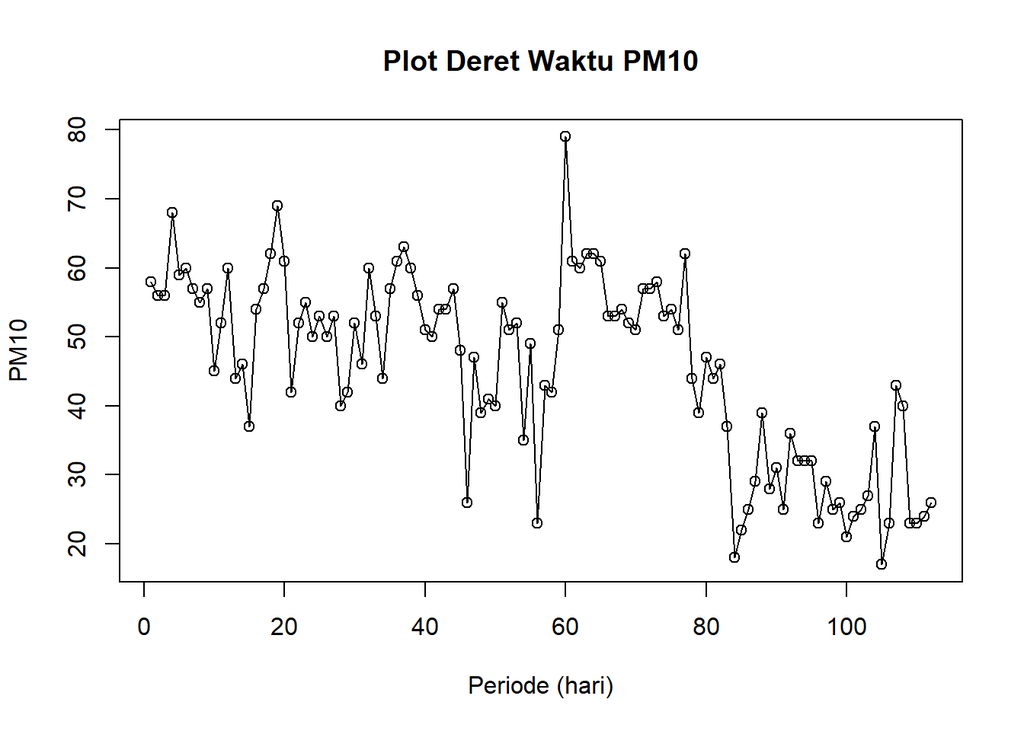

```r
ts.plot(data.ts, xlab = "Periode (hari)", ylab = "PM10",
        main = "Plot Deret Waktu PM10")
points(data.ts)
```

Plot deret waktu menunjukkan data berfluktuasi di kisaran 40-60 pada sekitar 80 periode pertama, kemudian terlihat kecenderungan menurun tajam menuju periode-periode akhir (turun ke kisaran 20-30-an). Pola ini mengindikasikan adanya sedikit tren menurun pada bagian akhir data, meskipun secara umum data masih relatif fluktuatif/tidak sepenuhnya stasioner.

## Single Moving Average & Double Moving Average

### Pembagian Data

Pembagian data latih dan data uji dilakukan dengan perbandingan 80% data latih dan 20% data uji.

```r
# hitung jumlah data
n <- nrow(data)

# tentukan batas 80%
n_train <- floor(0.8 * n)

# bagi data
training_ma <- data[1:n_train, ]
testing_ma  <- data[(n_train + 1):n, ]

# ubah ke time series
train_ma.ts <- ts(training_ma$pm10)
test_ma.ts  <- ts(testing_ma$pm10)
```

Eksplorasi data dilakukan pada keseluruhan data, data latih, serta data uji menggunakan plot data deret waktu.

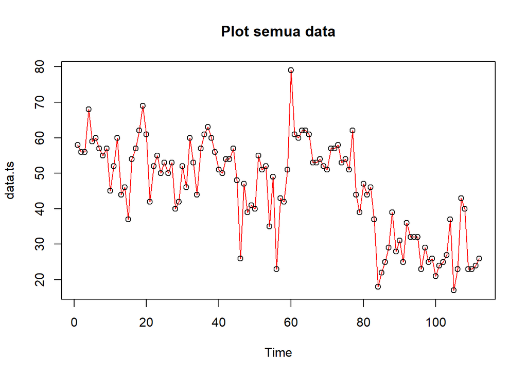

```r
#eksplorasi keseluruhan data
plot(data.ts, col = "red", main = "Plot semua data")
points(data.ts)
```

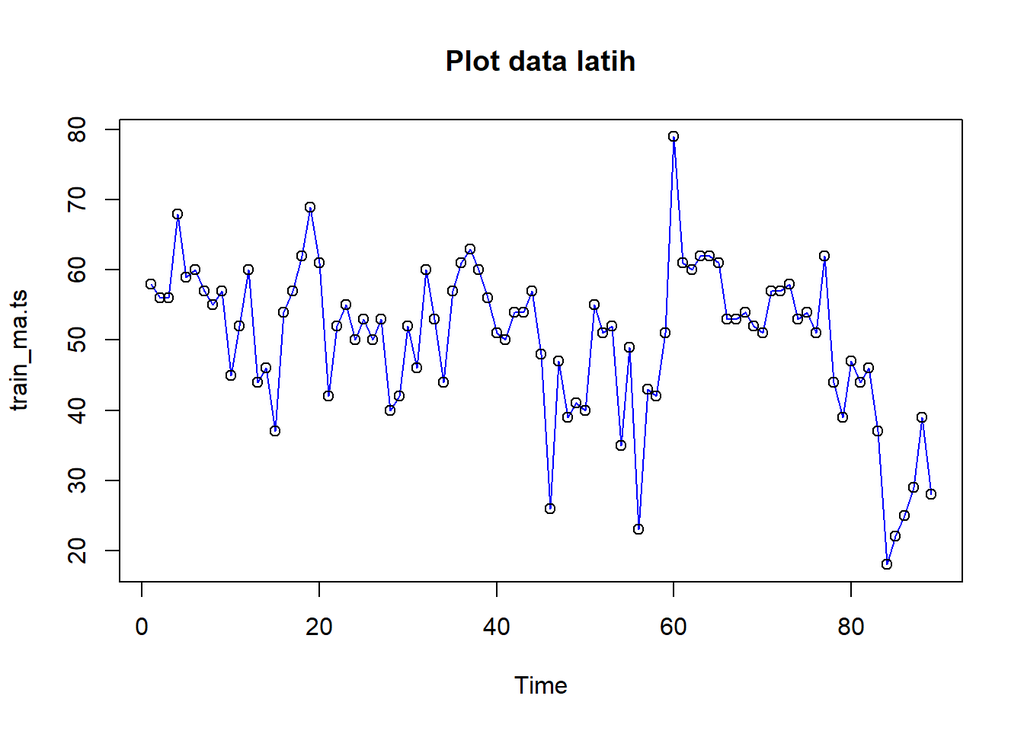

```r
#eksplorasi data latih
plot(train_ma.ts, col = "blue", main = "Plot data latih")
points(train_ma.ts)
```

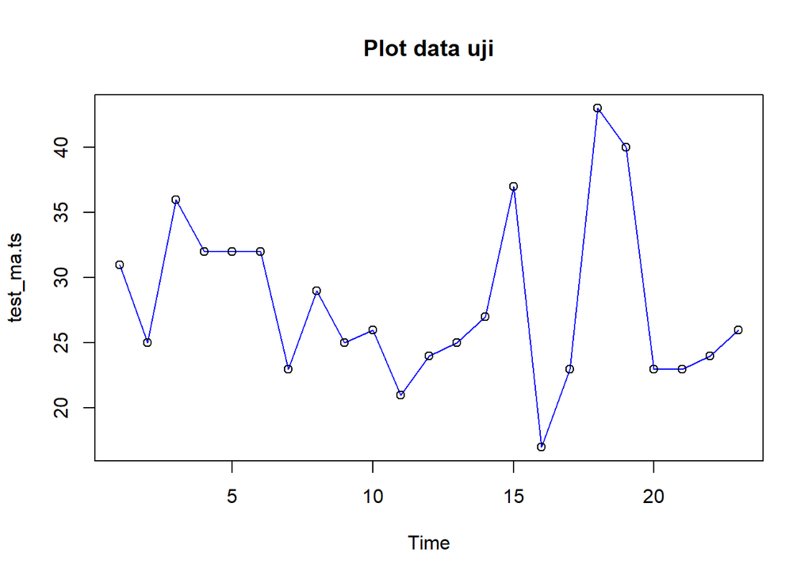

```r
#eksplorasi data uji
plot(test_ma.ts, col = "blue", main = "Plot data uji")
points(test_ma.ts)
```

Eksplorasi data juga dapat dilakukan menggunakan package `ggplot2`.

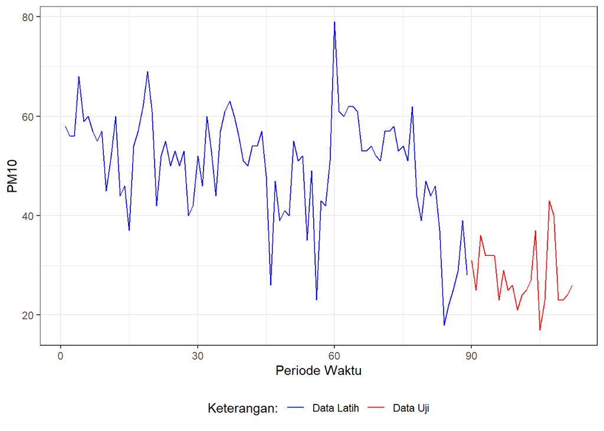

```r
ggplot() +
  geom_line(data = training_ma, aes(x = seq_along(pm10), y = pm10, col = "Data Latih")) +
  geom_line(data = testing_ma, aes(x = seq(n_train + 1, n), y = pm10, col = "Data Uji")) +
  labs(x = "Periode Waktu", y = "PM10", color = "Legend") +
  scale_colour_manual(name = "Keterangan:", breaks = c("Data Latih", "Data Uji"),
                       values = c("blue", "red")) +
  theme_bw() + theme(legend.position = "bottom",
                      plot.caption = element_text(hjust = 0.5, size = 12))
```

### Single Moving Average (SMA)

Ide dasar dari Single Moving Average (SMA) adalah data suatu periode dipengaruhi oleh data periode sebelumnya. Metode pemulusan ini cocok digunakan untuk pola data stasioner atau konstan. Pemulusan menggunakan metode SMA dilakukan dengan fungsi `SMA()`. Dalam hal ini akan dilakukan pemulusan dengan parameter m = 4.

```r
data.sma <- SMA(train_ma.ts, n = 4)
data.sma
```

```
## Time Series:
## Start = 1
## End = 89
## Frequency = 1
##  [1]    NA    NA    NA 59.50 59.75 60.75 61.00 57.75 57.25 53.50 52.25 53.50
## [13] 50.25 50.50 46.75 45.25 48.50 52.50 60.50 62.25 58.50 56.00 52.50 49.75
## [25] 52.50 52.00 51.50 49.00 46.25 46.75 45.00 50.00 52.75 50.75 53.50 53.75
## [37] 56.25 60.25 60.00 57.50 54.25 52.75 52.25 53.75 53.25 46.25 44.50 40.00
## [49] 38.25 41.75 43.75 46.75 49.50 48.25 46.75 39.75 37.50 39.25 39.75 53.75
## [61] 58.25 62.75 65.50 61.25 61.25 59.50 57.25 55.25 53.00 52.50 53.50 54.25
## [73] 55.75 56.25 55.50 54.00 55.00 52.75 49.00 48.00 43.50 44.00 43.50 36.25
## [85] 30.75 25.50 23.50 28.75 30.25
```

Nilai pemulusan SMA baru muncul mulai periode ke-4 (karena membutuhkan 4 data sebelumnya), dan nilainya relatif lebih stabil (halus) dibanding data aslinya karena merupakan rata-rata dari 4 periode terakhir.

Data pemulusan pada periode ke-t selanjutnya digunakan sebagai nilai peramalan pada periode ke t+1.

```r
data.ramal <- c(NA, data.sma)
data.ramal #forecast 1 periode ke depan
```

```
##  [1]    NA    NA    NA    NA 59.50 59.75 60.75 61.00 57.75 57.25 53.50 52.25
## [13] 53.50 50.25 50.50 46.75 45.25 48.50 52.50 60.50 62.25 58.50 56.00 52.50
## [25] 49.75 52.50 52.00 51.50 49.00 46.25 46.75 45.00 50.00 52.75 50.75 53.50
## [37] 53.75 56.25 60.25 60.00 57.50 54.25 52.75 52.25 53.75 53.25 46.25 44.50
## [49] 40.00 38.25 41.75 43.75 46.75 49.50 48.25 46.75 39.75 37.50 39.25 39.75
## [61] 53.75 58.25 62.75 65.50 61.25 61.25 59.50 57.25 55.25 53.00 52.50 53.50
## [73] 54.25 55.75 56.25 55.50 54.00 55.00 52.75 49.00 48.00 43.50 44.00 43.50
## [85] 36.25 30.75 25.50 23.50 28.75 30.25
```

Selanjutnya dilakukan peramalan sebanyak periode uji ke depan. Pada metode SMA, seluruh hasil peramalan untuk periode ke depan akan memiliki nilai yang sama dengan hasil ramalan satu periode ke depan.

```r
n_test <- nrow(testing_ma)

data.gab <- cbind(
  aktual    = c(data.ts),
  pemulusan = c(data.sma, rep(NA, n_test)),
  ramalan   = c(data.ramal, rep(data.ramal[length(data.ramal)], n_test - 1)))

data.gab #forecast periode uji ke depan
```

```
##        aktual pemulusan ramalan
##   [1,]     58        NA      NA
##   [2,]     56        NA      NA
##   [3,]     56        NA      NA
##   [4,]     68     59.50      NA
##   [5,]     59     59.75   59.50
##   [6,]     60     60.75   59.75
##   [7,]     57     61.00   60.75
##   [8,]     55     57.75   61.00
##   [9,]     57     57.25   57.75
##  [10,]     45     53.50   57.25
##  [11,]     52     52.25   53.50
##  [12,]     60     53.50   52.25
##  [13,]     44     50.25   53.50
##  [14,]     46     50.50   50.25
```

[output cut: 98 more lines]

Hasil pemulusan menggunakan metode SMA divisualisasikan sebagai berikut.

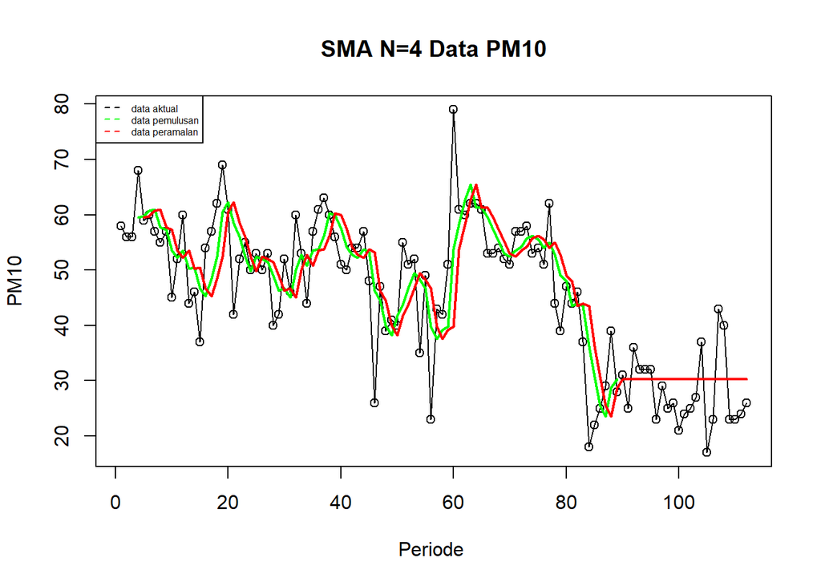

```r
ts.plot(data.ts, xlab = "Periode ", ylab = "PM10", main = "SMA N=4 Data PM10")
points(data.ts)
lines(data.gab[, 2], col = "green", lwd = 2)
lines(data.gab[, 3], col = "red", lwd = 2)
legend("topleft", c("data aktual", "data pemulusan", "data peramalan"),
       lty = 8, col = c("black", "green", "red"), cex = 0.5)
```

Selanjutnya perhitungan akurasi dilakukan baik pada data latih maupun data uji. Perhitungan akurasi dilakukan dengan ukuran akurasi SSE, MSE, dan MAPE.

```r
#Menghitung nilai keakuratan data latih
error_train.sma <- train_ma.ts - data.ramal[1:length(train_ma.ts)]

SSE_train.sma  <- sum(error_train.sma[5:length(train_ma.ts)]^2)
MSE_train.sma  <- mean(error_train.sma[5:length(train_ma.ts)]^2)
MAPE_train.sma <- mean(abs((error_train.sma[5:length(train_ma.ts)] /
                               train_ma.ts[5:length(train_ma.ts)]) * 100))

akurasi_train.sma <- matrix(c(SSE_train.sma, MSE_train.sma, MAPE_train.sma))
row.names(akurasi_train.sma) <- c("SSE", "MSE", "MAPE")
colnames(akurasi_train.sma) <- c("Akurasi m = 4")
akurasi_train.sma
```

```
##      Akurasi m = 4
## SSE     7999.12500
## MSE       94.10735
## MAPE      16.70790
```

Pada data latih, metode SMA (m=4) menghasilkan SSE sebesar 7999,13, MSE 94,11, dan MAPE 16,71%. Nilai MAPE ini berada pada kisaran 10-20%, sehingga menurut kriteria umum tergolong **baik**.

```r
#Menghitung nilai keakuratan data uji
error_test.sma <- test_ma.ts - data.gab[(n_train + 1):n, 3]
SSE_test.sma  <- sum(error_test.sma^2)
MSE_test.sma  <- mean(error_test.sma^2)
MAPE_test.sma <- mean(abs((error_test.sma / test_ma.ts) * 100))

akurasi_test.sma <- matrix(c(SSE_test.sma, MSE_test.sma, MAPE_test.sma))
row.names(akurasi_test.sma) <- c("SSE", "MSE", "MAPE")
colnames(akurasi_test.sma) <- c("Akurasi m = 4")
akurasi_test.sma
```

```
##      Akurasi m = 4
## SSE     1026.43750
## MSE       44.62772
## MAPE      22.57678
```

Pada data uji, SMA menghasilkan SSE 1026,44, MSE 44,63, dan MAPE 22,58%. Nilai MAPE data uji sedikit lebih tinggi dibanding data latih (16,71% menjadi 22,58%), tetapi masih tergolong **cukup baik** (di bawah 25%). Ini menunjukkan SMA cukup mampu menggeneralisasi pola PM10 walau ada penurunan performa saat diuji pada data baru.

### Double Moving Average (DMA)

Metode DMA merupakan pengembangan dari metode SMA, yaitu proses pemulusan rata-rata bergerak dilakukan sebanyak dua kali.

```r
data.sma_ <- SMA(train_ma.ts, n = 4)
data.dma  <- SMA(data.sma_, n = 4)

At <- 2 * data.sma_ - data.dma
Bt <- (2 / (4 - 1)) * (data.sma_ - data.dma)
data.ramal2 <- At + Bt

t  <- 1:n_test
f  <- c()
for (i in t) {
  f[i] <- At[length(At)] + Bt[length(Bt)] * (i)
}
data.gab2 <- cbind(aktual = c(data.ts),
                    pemulusan1 = c(data.sma_, rep(NA, n_test)),
                    pemulusan2 = c(data.dma, rep(NA, n_test)),
                    At = c(At, rep(NA, n_test)),
                    Bt = c(Bt, rep(NA, n_test)),
                    ramalan = c(data.ramal2, f))
data.gab2
```

```
##        aktual pemulusan1 pemulusan2      At          Bt  ramalan
##   [1,]     58         NA         NA      NA          NA       NA
##   [2,]     56         NA         NA      NA          NA       NA
##   [3,]     56         NA         NA      NA          NA       NA
##   [4,]     68      59.50         NA      NA          NA       NA
##   [5,]     59      59.75         NA      NA          NA       NA
##   [6,]     60      60.75         NA      NA          NA       NA
##   [7,]     57      61.00    60.2500 61.7500  0.50000000 62.25000
##   [8,]     55      57.75    59.8125 55.6875 -1.37500000 54.31250
##   [9,]     57      57.25    59.1875 55.3125 -1.29166667 54.02083
##  [10,]     45      53.50    57.3750 49.6250 -2.58333333 47.04167
##  [11,]     52      52.25    55.1875 49.3125 -1.95833333 47.35417
##  [12,]     60      53.50    54.1250 52.8750 -0.41666667 52.45833
##  [13,]     44      50.25    52.3750 48.1250 -1.41666667 46.70833
##  [14,]     46      50.50    51.6250 49.3750 -0.75000000 48.62500
```

[output cut: 98 more lines]

Hasil pemulusan menggunakan metode DMA divisualisasikan sebagai berikut.

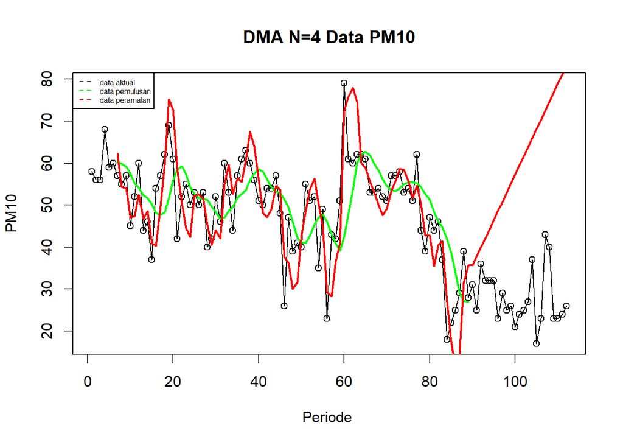

```r
ts.plot(data.ts, xlab = "Periode ", ylab = "PM10", main = "DMA N=4 Data PM10")
points(data.ts)
lines(data.gab2[, 3], col = "green", lwd = 2)
lines(data.gab2[, 6], col = "red", lwd = 2)
legend("topleft", c("data aktual", "data pemulusan", "data peramalan"),
       lty = 8, col = c("black", "green", "red"), cex = 0.5)
```

Selanjutnya perhitungan akurasi dilakukan baik pada data latih maupun data uji.

```r
#Menghitung nilai keakuratan data latih
error_train.dma <- train_ma.ts - data.ramal2[1:length(train_ma.ts)]

SSE_train.dma  <- sum(error_train.dma[8:length(train_ma.ts)]^2)
MSE_train.dma  <- mean(error_train.dma[8:length(train_ma.ts)]^2)
MAPE_train.dma <- mean(abs((error_train.dma[8:length(train_ma.ts)] /
                               train_ma.ts[8:length(train_ma.ts)]) * 100))

akurasi_train.dma <- matrix(c(SSE_train.dma, MSE_train.dma, MAPE_train.dma))
row.names(akurasi_train.dma) <- c("SSE", "MSE", "MAPE")
colnames(akurasi_train.dma) <- c("Akurasi m = 4")
akurasi_train.dma
```

```
##      Akurasi m = 4
## SSE     4383.92014
## MSE       53.46244
## MAPE      13.69895
```

Pada data latih, DMA menghasilkan SSE 4383,92, MSE 53,46, dan MAPE 13,70%. Nilai ini **lebih baik** dibanding SMA pada data latih (MAPE SMA 16,71% > MAPE DMA 13,70%), karena DMA mampu menangkap komponen tren pada data selain levelnya.

```r
#Menghitung nilai keakuratan data uji
error_test.dma <- test_ma.ts - data.gab2[(n_train + 1):n, 6]
SSE_test.dma  <- sum(error_test.dma^2)
MSE_test.dma  <- mean(error_test.dma^2)
MAPE_test.dma <- mean(abs((error_test.dma / test_ma.ts) * 100))

akurasi_test.dma <- matrix(c(SSE_test.dma, MSE_test.dma, MAPE_test.dma))
row.names(akurasi_test.dma) <- c("SSE", "MSE", "MAPE")
colnames(akurasi_test.dma) <- c("Akurasi m = 4")
akurasi_test.dma
```

```
##      Akurasi m = 4
## SSE     29080.5278
## MSE      1264.3708
## MAPE      125.4293
```

**Kesimpulan SMA vs DMA:** pada data latih, DMA lebih unggul karena mampu menangkap tren. Namun pada data uji, SMA jauh lebih stabil dan akurat (MAPE 22,58%) dibanding DMA yang MAPE-nya melonjak menjadi 125,43%. Ini menunjukkan DMA mengalami **overfitting** terhadap tren jangka pendek di akhir data latih sehingga generalisasinya buruk. Dengan demikian, **SMA (m=4) adalah pilihan yang lebih baik** dibanding DMA untuk meramalkan PM10 pada data ini.

## Single Exponential Smoothing & Double Exponential Smoothing

Metode Exponential Smoothing merupakan metode pemulusan deret waktu dengan memberikan bobot yang menurun secara eksponensial pada data historis, di mana nilai terbaru mendapat bobot lebih besar dibanding nilai yang lebih lama.

### Pembagian Data

Pembagian data latih dan data uji dilakukan dengan perbandingan 80% data latih dan 20% data uji (sama seperti sebelumnya).

```r
training <- data[1:n_train, ]
testing  <- data[(n_train + 1):n, ]

train.ts <- ts(training$pm10)
test.ts  <- ts(testing$pm10)
```

### Eksplorasi

Eksplorasi dilakukan dengan membuat plot data deret waktu untuk keseluruhan data, data latih, dan data uji.

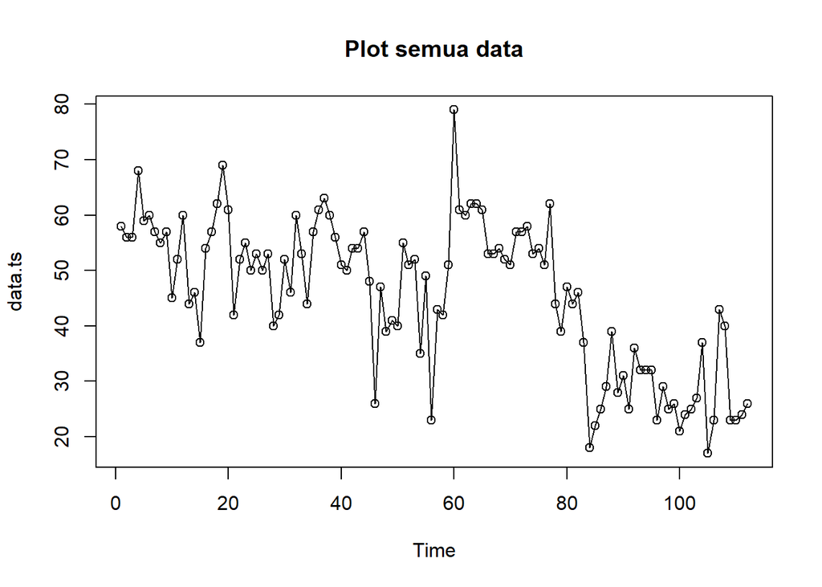

```r
plot(data.ts, col = "black", main = "Plot semua data")
points(data.ts)
```

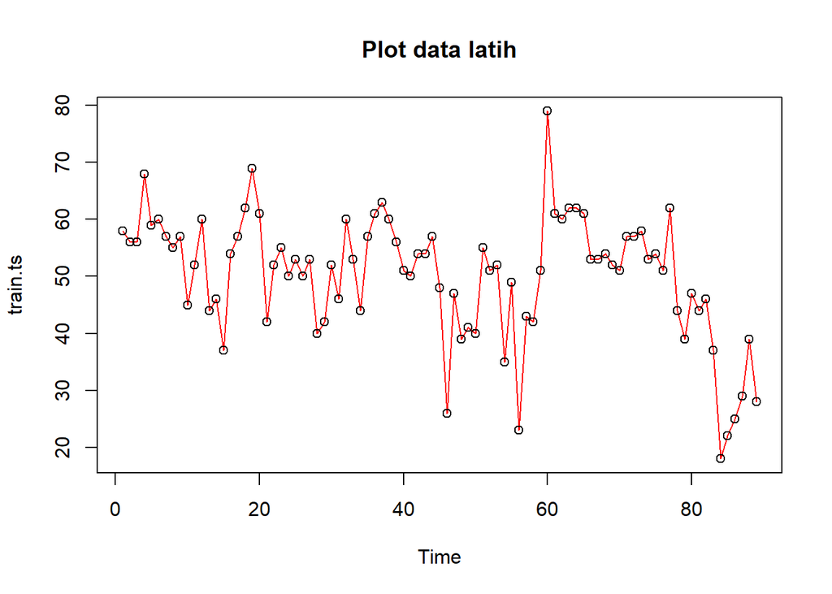

```r
plot(train.ts, col = "red", main = "Plot data latih")
points(train.ts)
```

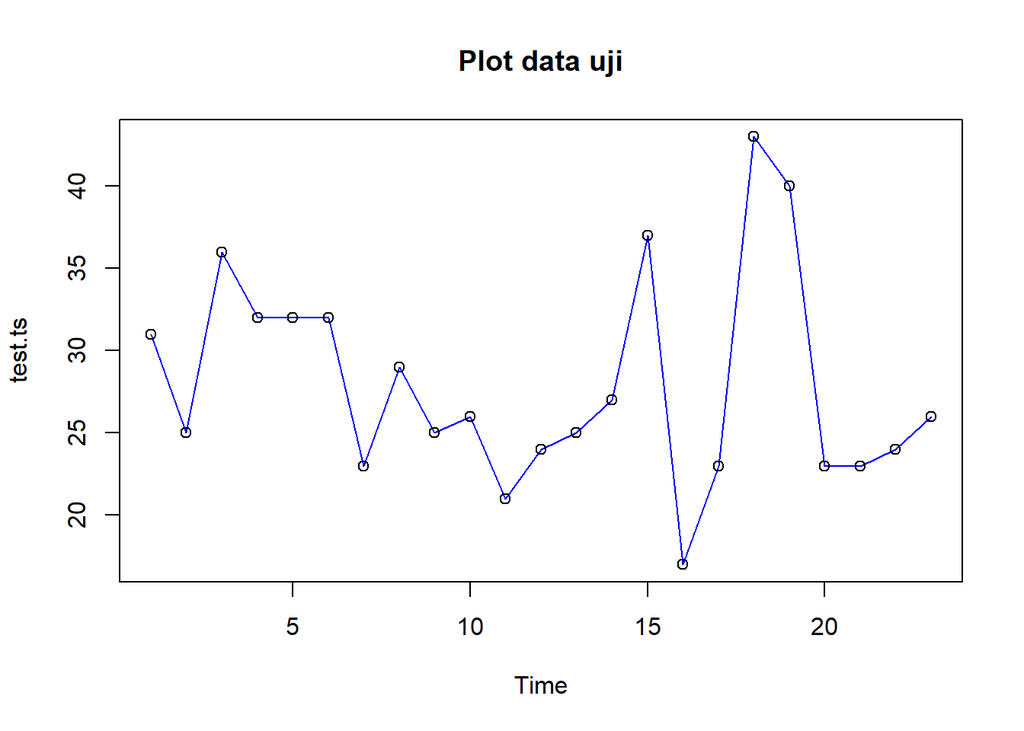

```r
plot(test.ts, col = "blue", main = "Plot data uji")
points(test.ts)
```

## Single Exponential Smoothing

Single Exponential Smoothing (SES) merupakan metode pemulusan yang tepat digunakan untuk data dengan pola stasioner atau konstan. Pemulusan dilakukan dengan fungsi `HoltWinters()`.

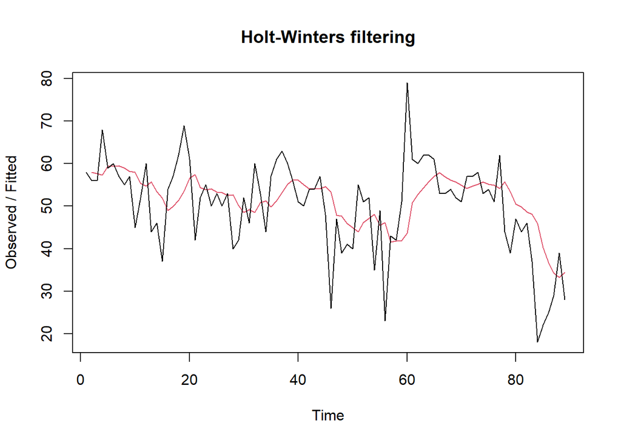

```r
# SES dengan alpha = 0.2
ses1 <- HoltWinters(train.ts, gamma = FALSE, beta = FALSE, alpha = 0.2)
plot(ses1)
```

```r
ramalan1 <- forecast(ses1, h = n_test)
ramalan1
```

```
##     Point Forecast    Lo 80    Hi 80     Lo 95    Hi 95
##  90        33.1244 21.19526 45.05353 14.880358 51.36844
##  91        33.1244 20.95902 45.28978 14.519054 51.72974
##  92        33.1244 20.72727 45.52152 14.164635 52.08416
##  93        33.1244 20.49979 45.74901 13.816721 52.43207
##  94        33.1244 20.27632 45.97247 13.474965 52.77383
##  95        33.1244 20.05668 46.19211 13.139053 53.10974
##  96        33.1244 19.84067 46.40812 12.808695 53.44010
##  97        33.1244 19.62812 46.62067 12.483623 53.76517
##  98        33.1244 19.41886 46.82993 12.163592 54.08520
##  99        33.1244 19.21275 47.03604 11.848374 54.40042
## 100        33.1244 19.00965 47.23914 11.537759 54.71103
## 101        33.1244 18.80943 47.43936 11.231550 55.01724
## 102        33.1244 18.61198 47.63682 10.929565 55.31923
## 103        33.1244 18.41717 47.83162 10.631635 55.61716
## 104        33.1244 18.22491 48.02388 10.337599 55.91119
## 105        33.1244 18.03510 48.21369 10.047310 56.20148
## 106        33.1244 17.84765 48.40114  9.760627 56.48817
## 107        33.1244 17.66247 48.58632  9.477419 56.77137
## 108        33.1244 17.47948 48.76931  9.197564 57.05123
## 109        33.1244 17.29861 48.95018  8.920944 57.32785
## 110        33.1244 17.11978 49.12901  8.647450 57.60134
## 111        33.1244 16.94293 49.30586  8.376978 57.87182
## 112        33.1244 16.76799 49.48080  8.109431 58.13936
```

Karena SES tidak memodelkan tren, seluruh titik ramalan untuk 23 periode ke depan bernilai konstan, yaitu 33,12 (dengan interval kepercayaan yang melebar seiring bertambahnya horizon peramalan).

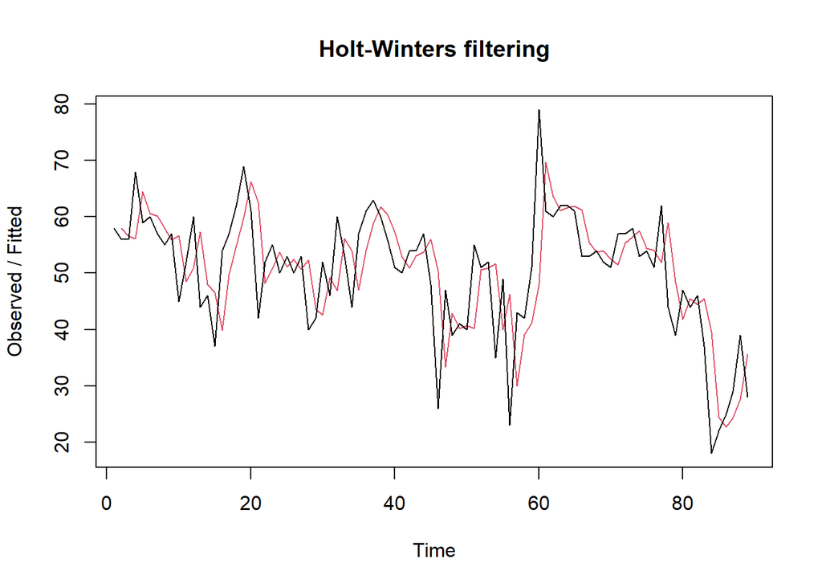

```r
# SES dengan alpha = 0.7
ses2 <- HoltWinters(train.ts, gamma = FALSE, beta = FALSE, alpha = 0.7)
plot(ses2)
```

```r
ramalan2 <- forecast(ses2, h = n_test)
ramalan2
```

```
##     Point Forecast       Lo 80    Hi 80        Lo 95    Hi 95
##  90        30.2737 18.75169165 41.79570  12.65231061 47.89508
##  91        30.2737 16.20929716 44.33810   8.76405377 51.78334
##  92        30.2737 14.06079848 46.48659   5.47820859 55.06918
##  93        30.2737 12.16544436 48.38195   2.57951461 57.96788
##  94        30.2737 10.45048967 50.09690  -0.04328226 60.59068
##  95        30.2737  8.87252217 51.67487  -2.45657529 63.00397
##  96        30.2737  7.40316969 53.14422  -4.70375598 65.25115
##  97        30.2737  6.02268147 54.52471  -6.81503053 67.36242
##  98        30.2737  4.71665317 55.83074  -8.81242845 69.35982
##  99        30.2737  3.47419655 57.07320 -10.71260187 71.26000
## 100        30.2737  2.28684367 58.26055 -12.52850140 73.07589
## 101        30.2737  1.14785463 59.39954 -14.27043482 74.81783
## 102        30.2737  0.05176078 60.49563 -15.94676570 76.49416
## 103        30.2737 -1.00594756 61.55334 -17.56439101 78.11178
## 104        30.2737 -2.02904125 62.57643 -19.12907779 79.67647
## 105        30.2737 -3.02071144 63.56810 -20.64570647 81.19310
## 106        30.2737 -3.98368714 64.53108 -22.11845071 82.66584
## 107        30.2737 -4.92032384 65.46772 -23.55091293 84.09831
## 108        30.2737 -5.83267138 66.38006 -24.94622809 85.49362
## 109        30.2737 -6.72252676 67.26992 -26.30714445 86.85454
## 110        30.2737 -7.59147575 68.13887 -27.63608724 88.18348
## 111        30.2737 -8.44092610 68.98832 -28.93520945 89.48260
## 112        30.2737 -9.27213434 69.81953 -30.20643276 90.75383
```

Dengan alpha yang lebih besar (0,7), bobot terhadap observasi terakhir menjadi lebih besar sehingga nilai ramalan konstannya berubah menjadi 30,27, sedikit lebih rendah dari alpha=0,2 dan lebih mendekati level PM10 pada akhir data latih.

Nilai parameter alpha dapat dioptimalkan menyesuaikan dari error-nya paling minimum, dengan membuat argumen alpha = NULL.

```r
HWopt <- HoltWinters(train.ts, gamma = FALSE, beta = FALSE, alpha = NULL)
HWopt
```

```
## Holt-Winters exponential smoothing without trend and without seasonal component.
##
## Call:
## HoltWinters(x = train.ts, alpha = NULL, beta = FALSE, gamma = FALSE)
##
## Smoothing parameters:
##  alpha: 0.5080408
##  beta : FALSE
##  gamma: FALSE
##
## Coefficients:
##       [,1]
## a 30.55248
```

```r
ramalanopt <- forecast(HWopt, h = n_test)
ramalanopt
```

```
##     Point Forecast     Lo 80    Hi 80       Lo 95    Hi 95
##  90       30.55248 19.199619 41.90534  13.1897769 47.91518
##  91       30.55248 17.818509 43.28645  11.0775520 50.02741
##  92       30.55248 16.573189 44.53177   9.1729996 51.93196
##  93       30.55248 15.430075 45.67489   7.4247575 53.68020
##  94       30.55248 14.367497 46.73746   5.7996840 55.30528
##  95       30.55248 13.370506 47.73446   4.2749178 56.83004
##  96       30.55248 12.428275 48.67669   2.8339007 58.27106
##  97       30.55248 11.532665 49.57230   1.4641833 59.64078
##  98       30.55248 10.677372 50.42759   0.1561255 60.94884
##  99       30.55248  9.857397 51.24756  -1.0979186 62.20288
## 100       30.55248  9.068695 52.03627  -2.3041342 63.40910
## 101       30.55248  8.307940 52.79702  -3.4676090 64.57257
## 102       30.55248  7.572355 53.53261  -4.5925883 65.69755
## 103       30.55248  6.859597 54.24536  -5.6826575 66.78762
## 104       30.55248  6.167664 54.93730  -6.7408780 67.84584
## 105       30.55248  5.494830 55.61013  -7.7698884 68.87485
## 106       30.55248  4.839597 56.26536  -8.7719816 69.87694
## 107       30.55248  4.200651 56.90431  -9.7491657 70.85413
## 108       30.55248  3.576834 57.52813 -10.7032106 71.80817
## 109       30.55248  2.967121 58.13784 -11.6356863 72.74065
## 110       30.55248  2.370596 58.73437 -12.5479926 73.65295
## 111       30.55248  1.786439 59.31852 -13.4413844 74.54635
## 112       30.55248  1.213910 59.89105 -14.3169915 75.42195
```

Nilai alpha optimum yang dihasilkan adalah 0,508 (di antara 0,2 dan 0,7), dengan nilai ramalan konstan sebesar 30,55, mirip dengan hasil pada alpha=0,7.

### Akurasi Data Latih

```r
# alpha = 0.2
SSE1  <- ses1$SSE
MSE1  <- ses1$SSE / length(train.ts)
RMSE1 <- sqrt(MSE1)

akurasi1 <- matrix(c(SSE1, MSE1, RMSE1))
row.names(akurasi1) <- c("SSE", "MSE", "RMSE")
colnames(akurasi1) <- c("Akurasi alpha=0.2")
akurasi1
```

```
##      Akurasi alpha=0.2
## SSE        7713.949125
## MSE          86.673586
## RMSE          9.309865
```

```r
# alpha = 0.7
SSE2  <- ses2$SSE
MSE2  <- ses2$SSE / length(train.ts)
RMSE2 <- sqrt(MSE2)

akurasi2 <- matrix(c(SSE2, MSE2, RMSE2))
row.names(akurasi2) <- c("SSE", "MSE", "RMSE")
colnames(akurasi2) <- c("Akurasi alpha=0.7")
akurasi2
```

```
##      Akurasi alpha=0.7
## SSE        7050.222262
## MSE          79.215980
## RMSE          8.900336
```

```r
# alpha optimum
SSEopt  <- HWopt$SSE
MSEopt  <- HWopt$SSE / length(train.ts)
RMSEopt <- sqrt(MSEopt)

akurasiopt <- matrix(c(SSEopt, MSEopt, RMSEopt))
row.names(akurasiopt) <- c("SSE", "MSE", "RMSE")
colnames(akurasiopt) <- c("Akurasi optimum")
akurasiopt
```

```
##      Akurasi optimum
## SSE      6860.606847
## MSE        77.085470
## RMSE        8.779833
```

Pada data latih, ketiga model SES menghasilkan RMSE yang relatif berdekatan: alpha=0,2 (RMSE 9,31), alpha=0,7 (RMSE 8,90), dan alpha optimum (RMSE 8,78). Model dengan alpha optimum memberikan hasil **terbaik** pada data latih karena RMSE-nya paling kecil.

### Akurasi Data Uji

```r
# jumlah observasi uji
n_test2 <- nrow(testing)

e1   <- as.numeric(ramalan1$mean)[1:n_test2] - as.numeric(testing$pm10)
e2   <- as.numeric(ramalan2$mean)[1:n_test2] - as.numeric(testing$pm10)
eopt <- as.numeric(ramalanopt$mean)[1:n_test2] - as.numeric(testing$pm10)

SSEtesting1  <- sum(e1^2,  na.rm = TRUE)
MSEtesting1  <- mean(e1^2, na.rm = TRUE)
RMSEtesting1 <- sqrt(MSEtesting1)

SSEtesting2  <- sum(e2^2,  na.rm = TRUE)
MSEtesting2  <- mean(e2^2, na.rm = TRUE)
RMSEtesting2 <- sqrt(MSEtesting2)

SSEtestingopt  <- sum(eopt^2,  na.rm = TRUE)
MSEtestingopt  <- mean(eopt^2, na.rm = TRUE)
RMSEtestingopt <- sqrt(MSEtestingopt)

akurasitesting_SES <- data.frame(
  Model = c("alpha=0.2", "alpha=0.7", "alpha optimum"),
  SSE   = c(SSEtesting1, SSEtesting2, SSEtestingopt),
  MSE   = c(MSEtesting1, MSEtesting2, MSEtestingopt),
  RMSE  = c(RMSEtesting1, RMSEtesting2, RMSEtestingopt)
)
akurasitesting_SES
```

```
##           Model      SSE      MSE     RMSE
## 1     alpha=0.2 1513.967 65.82466 8.113240
## 2     alpha=0.7 1028.903 44.73491 6.688416
## 3 alpha optimum 1059.849 46.08038 6.788253
```

Pada data uji, urutannya sedikit berubah: alpha=0,7 memberikan RMSE terkecil (6,69), disusul alpha optimum (RMSE 6,79), lalu alpha=0,2 (RMSE 8,11). Artinya, model dengan alpha=0,7 (dan alpha optimum yang nilainya berdekatan, yaitu 0,508) memberikan hasil peramalan yang **paling akurat** pada data uji, karena bobot yang lebih besar pada observasi terbaru ternyata lebih sesuai dengan karakteristik data PM10 yang cukup fluktuatif ini. Secara keseluruhan, **model SES dengan alpha optimum (≈0,508)** dipilih sebagai model SES terbaik karena performanya konsisten baik pada data latih maupun data uji.

## Double Exponential Smoothing (DES)

Metode DES digunakan untuk data yang memiliki pola tren. Metode ini merupakan pengembangan SES, dilakukan dua kali pemulusan, yaitu untuk tahap ‘level’ dan tahap ‘tren’.

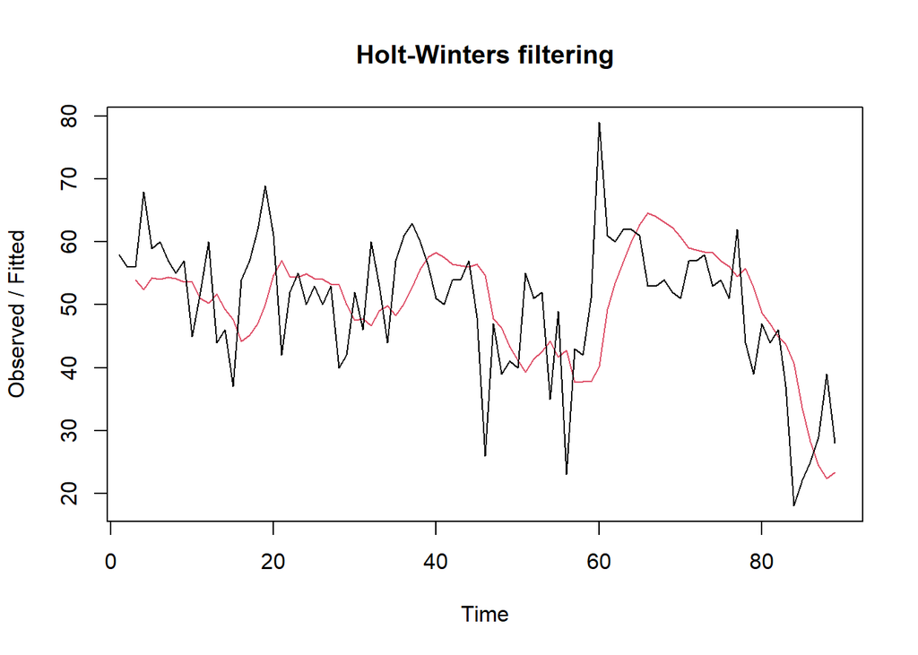

```r
#alpha=0.2, beta=0.2
des.1 <- HoltWinters(train.ts, gamma = FALSE, beta = 0.2, alpha = 0.2)
plot(des.1)
```

```r
ramalandes1 <- forecast(des.1, h = n_test)
ramalandes1
```

```
##     Point Forecast      Lo 80    Hi 80       Lo 95    Hi 95
##  90     22.1131347   9.267951 34.95832   2.4681219 41.75815
##  91     19.9677319   6.757786 33.17768  -0.2351367 40.17060
##  92     17.8223291   4.131509 31.51315  -3.1159741 38.76063
##  93     15.6769262   1.382367 29.97149  -6.1847163 37.53857
##  94     13.5315234  -1.492400 28.55545  -9.4455846 36.50863
##  95     11.3861206  -4.492106 27.26435 -12.8975311 35.66977
##  96      9.2407178  -7.613416 26.09485 -16.5354556 35.01689
##  97      7.0953149 -10.851204 25.04183 -20.3515171 34.54215
##  98      4.9499121 -14.199323 24.09915 -24.3363154 34.23614
##  99      2.8045093 -17.651219 23.26024 -28.4798268 34.08885
## 100      0.6591064 -21.200362 22.51857 -32.7720651 34.09028
## 101     -1.4862964 -24.840521 21.86793 -37.2035015 34.23091
## 102     -3.6316992 -28.565918 21.30252 -41.7652955 34.50190
## 103     -5.7771020 -32.371285 20.81708 -46.4493958 34.89519
## 104     -7.9225049 -36.251887 20.40688 -51.2485553 35.40355
## 105    -10.0679077 -40.203486 20.06767 -56.1562969 36.02048
## 106    -12.2133105 -44.222312 19.79569 -61.1668536 36.74023
## 107    -14.3587133 -48.305012 19.58759 -66.2750970 37.55767
## 108    -16.5041162 -52.448603 19.44037 -71.4764647 38.46823
## 109    -18.6495190 -56.650426 19.35139 -76.7668916 39.46785
## 110    -20.7949218 -60.908108 19.31826 -82.1427459 40.55290
## 111    -22.9403247 -65.219520 19.33887 -87.6007736 41.72012
## 112    -25.0857275 -69.582748 19.41129 -93.1380483 42.96659
```

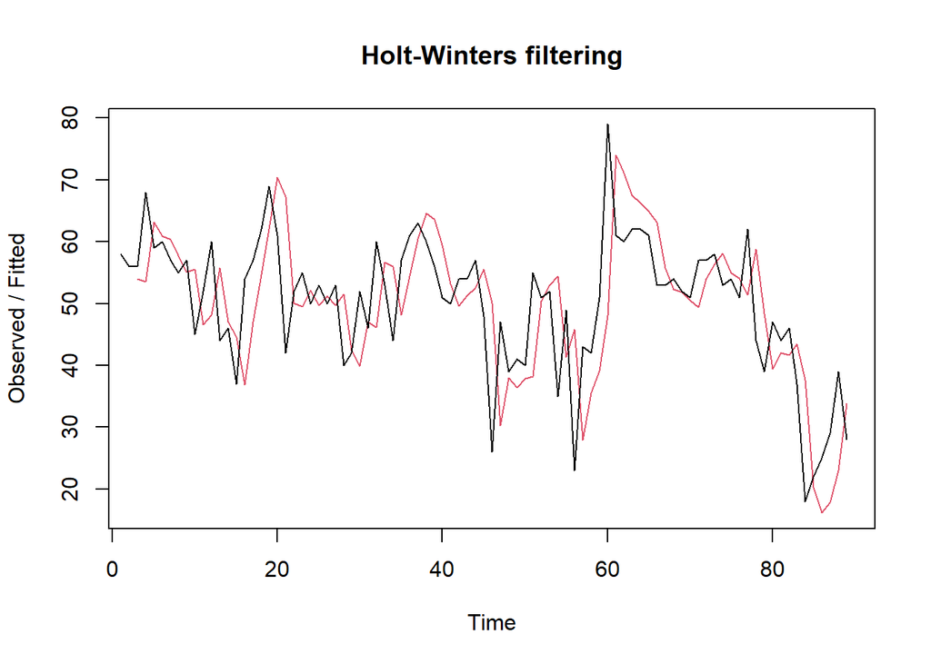

```r
#alpha=0.6, beta=0.3
des.2 <- HoltWinters(train.ts, gamma = FALSE, beta = 0.3, alpha = 0.6)
plot(des.2)
```

```r
ramalandes2 <- forecast(des.2, h = n_test)
ramalandes2
```

```
##     Point Forecast       Lo 80     Hi 80         Lo 95     Hi 95
##  90       30.58509   17.818102  43.35208  1.105967e+01  50.11051
##  91       30.82131   14.629874  47.01275  6.058644e+00  55.58398
##  92       31.05754   10.750401  51.36467  4.521172e-04  62.11462
##  93       31.29376    6.309579  56.27794 -6.916248e+00  69.50377
##  94       31.52998    1.393404  61.66657 -1.455994e+01  77.61991
##  95       31.76621   -3.940295  67.47271 -2.284218e+01  86.37459
##  96       32.00243   -9.650829  73.65569 -3.170073e+01  95.70560
##  97       32.23866  -15.708137  80.18545 -4.108964e+01 105.56695
##  98       32.47488  -22.089018  87.03878 -5.097340e+01 115.92316
##  99       32.71110  -28.774897  94.19711 -6.132362e+01 126.74583
## 100       32.94733  -35.750452 101.64511 -7.211686e+01 138.01152
## 101       33.18355  -43.002742 109.36985 -8.333333e+01 149.70043
## 102       33.41978  -50.520616 117.36017 -9.495598e+01 161.79553
## 103       33.65600  -58.294320 125.60632 -1.069699e+02 174.28188
## 104       33.89222  -66.315207 134.09966 -1.193618e+02 187.14626
## 105       34.12845  -74.575532 142.83243 -1.321199e+02 200.37684
## 106       34.36467  -83.068294 151.79764 -1.452336e+02 213.96290
## 107       34.60090  -91.787119 160.98891 -1.586929e+02 227.89468
## 108       34.83712 -100.726162 170.40040 -1.724890e+02 242.16327
## 109       35.07334 -109.880040 180.02673 -1.866137e+02 256.76041
## 110       35.30957 -119.243764 189.86290 -2.010594e+02 271.67849
## 111       35.54579 -128.812694 199.90428 -2.158188e+02 286.91040
## 112       35.78202 -138.582501 210.14653 -2.308855e+02 302.44953
```

Dengan alpha=0,6;beta=0,3, tren yang tertangkap justru sedikit positif dan landai, sehingga nilai ramalan naik perlahan dari 30,59 menuju 35,78 pada akhir periode uji, jauh lebih realistis dibanding kombinasi parameter sebelumnya.

Nilai parameter alpha dan beta dapat dioptimalkan menyesuaikan errornya, dengan membuat argumen alpha dan beta menjadi NULL.

```r
des.opt <- HoltWinters(train.ts, gamma = FALSE)
des.opt
```

```
## Holt-Winters exponential smoothing with trend and without seasonal component.
##
## Call:
## HoltWinters(x = train.ts, gamma = FALSE)
##
## Smoothing parameters:
##  alpha: 0.5584016
##  beta : 0.02799055
##  gamma: FALSE
##
## Coefficients:
##         [,1]
## a 29.9889848
## b -0.6777587
```

```r
ramalandesopt <- forecast(des.opt, h = n_test)
ramalandesopt
```

```
##     Point Forecast        Lo 80    Hi 80      Lo 95    Hi 95
##  90       29.31123  17.66019901 40.96225  11.492518 47.12993
##  91       28.63347  15.19931160 42.06762   8.087699 49.17924
##  92       27.95571  12.86678317 43.04463   4.879188 51.03223
##  93       27.27795  10.62231576 43.93358   1.805356 52.75054
##  94       26.60019   8.44127336 44.75911  -1.171477 54.37186
##  95       25.92243   6.30737600 45.53749  -4.076208 55.92107
##  96       25.24467   4.20925352 46.28009  -6.926225 57.41557
##  97       24.56692   2.13862904 46.99520  -9.734188 58.86802
##  98       23.88916   0.08928047 47.68903 -12.509613 60.28793
##  99       23.21140  -1.94359120 48.36639 -15.259838 61.68263
## 100       22.53364  -3.96376574 49.03104 -17.990645 63.05792
## 101       21.85588  -5.97427227 49.68603 -20.706665 64.41843
## 102       21.17812  -7.97757413 50.33382 -23.411667 65.76791
## 103       20.50036  -9.97569964 50.97643 -26.108753 67.10948
## 104       19.82260 -11.97033682 51.61555 -28.800503 68.44571
## 105       19.14485 -13.96290361 52.25259 -31.489087 69.77878
## 106       18.46709 -15.95460068 52.88877 -34.176341 71.11052
## 107       17.78933 -17.94645198 53.52511 -36.863831 72.44249
## 108       17.11157 -19.93933615 54.16248 -39.552901 73.77604
## 109       16.43381 -21.93401131 54.80163 -42.244709 75.11233
## 110       15.75605 -23.93113477 55.44324 -44.940262 76.45237
## 111       15.07829 -25.93127889 56.08787 -47.640435 77.79702
## 112       14.40053 -27.93494392 56.73601 -50.345993 79.14706
```

Parameter optimum yang diperoleh adalah alpha=0,558 dan beta=0,028 (beta yang kecil), dengan komponen tren negatif (-0,678) yang diekstrapolasi terus-menerus sehingga nilai ramalan menurun dari 29,31 menjadi 14,40 pada akhir periode uji.

Perbandingan plot data latih dan hasil pemulusan.

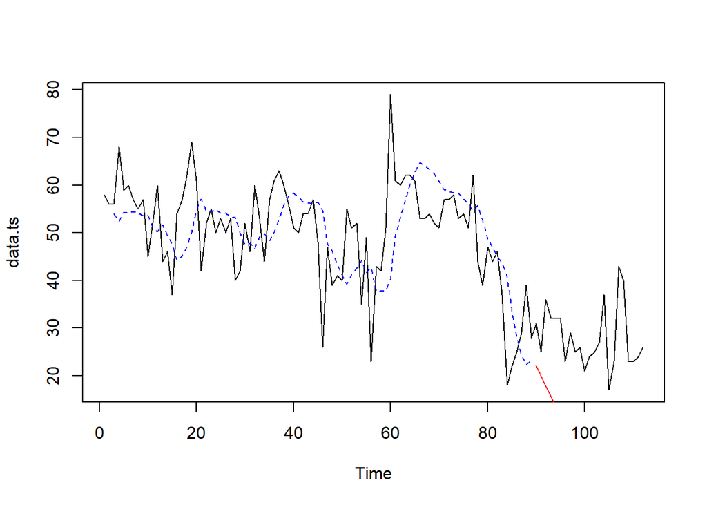

```r
plot(data.ts)
lines(des.1$fitted[, 1], lty = 2, col = "blue")
lines(ramalandes1$mean, col = "red")
```

### Akurasi Data Latih

```r
SSE.des1  <- des.1$SSE
MSE.des1  <- des.1$SSE / length(train.ts)
RMSE.des1 <- sqrt(MSE.des1)

SSE.des2  <- des.2$SSE
MSE.des2  <- des.2$SSE / length(train.ts)
RMSE.des2 <- sqrt(MSE.des2)

SSE.desopt  <- des.opt$SSE
MSE.desopt  <- des.opt$SSE / length(train.ts)
RMSE.desopt <- sqrt(MSE.desopt)

akurasi_des_train <- data.frame(
  Model = c("alpha=0.2;beta=0.2", "alpha=0.6;beta=0.3", "optimum"),
  SSE   = c(SSE.des1, SSE.des2, SSE.desopt),
  MSE   = c(MSE.des1, MSE.des2, MSE.desopt),
  RMSE  = c(RMSE.des1, RMSE.des2, RMSE.desopt)
)
akurasi_des_train
```

```
##                Model      SSE      MSE     RMSE
## 1 alpha=0.2;beta=0.2 8640.016 97.07883 9.852859
## 2 alpha=0.6;beta=0.3 8536.766 95.91872 9.793810
## 3            optimum 7190.379 80.79077 8.988369
```

Pada data latih, parameter optimum (alpha=0,558;beta=0,028) memberikan RMSE terkecil (8,99), sedikit lebih baik dibanding alpha=0,2;beta=0,2 (RMSE 9,85) dan alpha=0,6;beta=0,3 (RMSE 9,79).

### Akurasi Data Uji

```r
ed1   <- as.numeric(ramalandes1$mean)[1:n_test2] - as.numeric(testing$pm10)
ed2   <- as.numeric(ramalandes2$mean)[1:n_test2] - as.numeric(testing$pm10)
edopt <- as.numeric(ramalandesopt$mean)[1:n_test2] - as.numeric(testing$pm10)

akurasi_des_test <- data.frame(
  Model = c("alpha=0.2;beta=0.2", "alpha=0.6;beta=0.3", "optimum"),
  SSE   = c(sum(ed1^2, na.rm = TRUE), sum(ed2^2, na.rm = TRUE), sum(edopt^2, na.rm = TRUE)),
  MSE   = c(mean(ed1^2, na.rm = TRUE), mean(ed2^2, na.rm = TRUE), mean(edopt^2, na.rm = TRUE))
)
akurasi_des_test
```

```
##                Model       SSE        MSE
## 1 alpha=0.2;beta=0.2 24973.014 1085.78320
## 2 alpha=0.6;beta=0.3  1649.661   71.72440
## 3            optimum  2056.062   89.39402
```

Pada data uji, hasilnya sangat kontras dengan hasil di data latih. Parameter alpha=0,2;beta=0,2 (yang forecast-nya sempat negatif) memberikan MSE **sangat buruk** (1085,78). Sebaliknya, alpha=0,6;beta=0,3 justru memberikan MSE **terkecil** (71,72), diikuti parameter optimum (MSE 89,39). Ini menunjukkan bahwa parameter “optimum” hasil optimisasi `HoltWinters()` (yang meminimumkan SSE pada data *latih*) belum tentu memberikan hasil terbaik pada data *uji*, komponen tren negatif yang diekstrapolasi terlalu jauh ke depan justru merugikan akurasi.

### Perbandingan SES dan DES

```r
perbandingan <- data.frame(
  Metode = c("SES (alpha optimum)", "DES (optimum)"),
  SSE_train = c(SSEopt, SSE.desopt),
  MSE_train = c(MSEopt, MSE.desopt),
  SSE_test  = c(SSEtestingopt, sum(edopt^2, na.rm = TRUE)),
  MSE_test  = c(MSEtestingopt, mean(edopt^2, na.rm = TRUE))
)
perbandingan
```

```
##                Metode SSE_train MSE_train SSE_test MSE_test
## 1 SES (alpha optimum)  6860.607  77.08547 1059.849 46.08038
## 2       DES (optimum)  7190.379  80.79077 2056.062 89.39402
```

Berdasarkan tabel di atas, model **SES (alpha optimum)** memiliki MSE data latih yang lebih kecil (77,09 vs 80,79) maupun MSE data uji yang jauh lebih kecil (46,08 vs 89,39) dibanding DES (optimum). Hal ini masuk akal karena data PM10 pada kasus ini tidak menunjukkan tren yang konsisten/kuat, melainkan cenderung berfluktuasi di sekitar suatu level tertentu. Akibatnya, komponen tren yang dipaksakan oleh DES justru menyesatkan hasil peramalan, sedangkan SES yang hanya memodelkan level lebih sesuai dengan karakteristik data ini. Dengan demikian, **SES lebih baik dibanding DES** untuk data PM10 pada kasus ini.

## Pemulusan Data Musiman

Data PM10 harian berpotensi memiliki pola musiman mingguan, sehingga pada bagian ini data diubah menjadi deret waktu dengan frekuensi 7 (musiman mingguan).

```r
training.ts <- ts(training$pm10, frequency = 7)
testing.ts  <- ts(testing$pm10, frequency = 7)
```

Eksplorasi dengan plot data deret waktu.

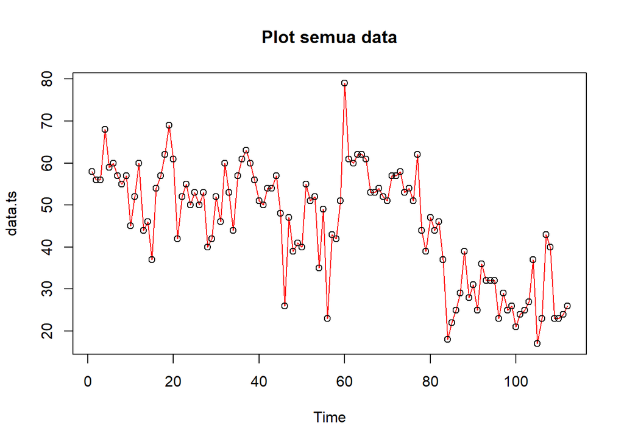

```r
plot(data.ts, col = "red", main = "Plot semua data")
points(data.ts)
```

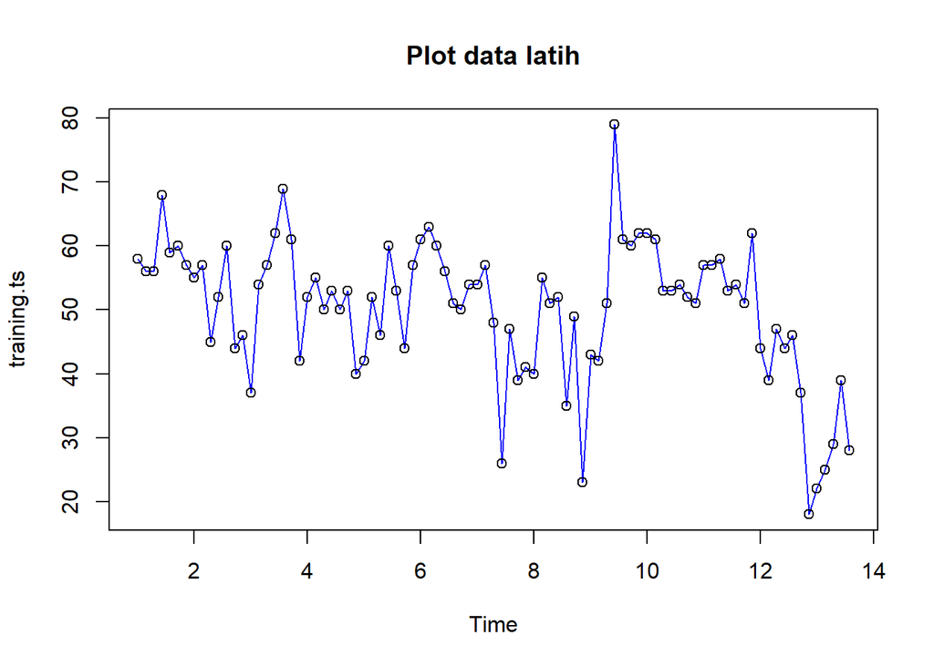

```r
plot(training.ts, col = "blue", main = "Plot data latih")
points(training.ts)
```

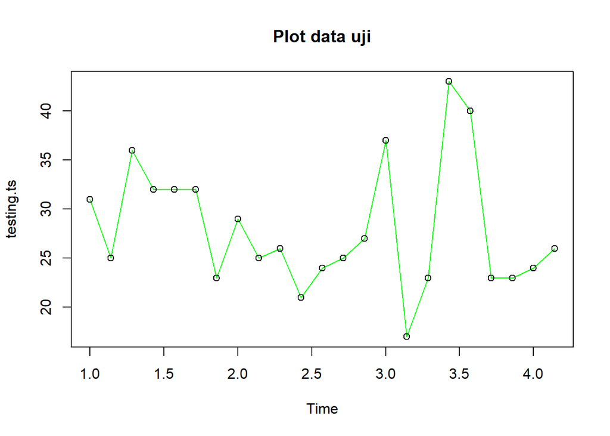

```r
plot(testing.ts, col = "green", main = "Plot data uji")
points(testing.ts)
```

Secara visual, fluktuasi musiman pada data PM10 ini terlihat relatif stabil (tidak membesar/mengecil seiring waktu), sehingga model Winter aditif diperkirakan cukup sesuai, namun model multiplikatif tetap dicoba sebagai pembanding.

Metode Holt-Winter untuk peramalan data musiman menggunakan tiga persamaan pemulusan yaitu level, trend, dan komponen musiman, dengan parameter pemulusan alpha, beta, dan gamma. Metode Holt-Winter musiman terbagi menjadi dua, yaitu metode aditif dan metode multiplikatif.

### Winter Aditif

Perhitungan dengan model aditif dilakukan jika plot data asli menunjukkan fluktuasi musiman yang relatif stabil (konstan).

#### Pemulusan

```r
winter1 <- HoltWinters(training.ts, alpha = 0.2, beta = 0.1, gamma = 0.1, seasonal = "additive")
winter1$fitted
```

```
## Time Series:
## Start = c(2, 1)
## End = c(13, 5)
## Frequency = 7
##               xhat    level       trend      season
##  2.000000 60.11735 61.27041 -1.16326531  0.01020408
##  2.142857 59.68541 59.08367 -1.26561224  1.86734694
##  2.285714 48.11472 57.28098 -1.31932041 -7.84693878
##  2.428571 58.75302 55.33872 -1.38161482  4.79591837
##  2.571429 51.38574 52.60650 -1.51667519  0.29591837
##  2.714286 52.62134 52.81267 -1.34438998  1.15306122
##  2.857143 47.95169 49.74401 -1.51681688 -0.27551020
##  3.000000 45.88183 47.83686 -1.55585063 -0.39918367
##  3.142857 44.42367 44.50464 -1.73348714  1.65251429
##  3.285714 35.04835 44.68642 -1.54196057 -8.09611641
##  3.428571 50.68754 47.53479 -1.10292749  4.25567688
##  3.571429 48.80274 48.69436 -0.87667834  0.98505919
##  3.714286 51.84775 51.85713 -0.47273310  0.46335365
##  3.857143 52.49351 53.21485 -0.28968814 -0.43164520
##  4.000000 49.21717 50.82646 -0.49955843 -1.10972974
##  4.142857 52.85818 50.88346 -0.44390180  2.41862057
##  4.285714 44.12688 50.86793 -0.40106546 -6.33998408
##  4.428571 56.51856 51.64149 -0.28360300  5.16067347
##  4.571429 52.90104 50.65417 -0.35397411  2.60084015
##  4.714286 50.50353 49.71999 -0.41199486  1.19553351
##  4.857143 48.17410 49.80729 -0.36206542 -1.27112635
##  5.000000 46.39775 47.81040 -0.52554737 -0.88710323
##  5.142857 48.38177 46.40531 -0.61350244  2.58996590
##  5.285714 40.10418 46.51545 -0.54113783 -5.87013421
##  5.428571 51.60944 47.15348 -0.42322139  4.87918901
##  5.571429 50.52171 48.40837 -0.25541027  2.36875717
##  5.714286 49.83802 48.64861 -0.20584453  1.39525125
##  5.857143 45.02751 47.27516 -0.32260493 -1.92505414
##  6.000000 48.02498 49.34706 -0.08315505 -1.23892352
##  6.142857 54.91468 51.85891  0.17634535  2.87942433
##  6.285714 48.59190 53.65232  0.33805181 -5.39846843
##  6.428571 62.38864 56.27199  0.56621379  5.55043349
##  6.571429 58.56594 55.56048  0.43844106  2.56702012
##  6.714286 55.70106 54.48573  0.28712232  0.92820965
##  6.857143 52.83849 53.63264  0.17310110 -0.96725460
```

[output cut: 32 more lines]

```
## 11.571429 57.15920 55.64784  0.21411266  1.29725250
## 11.714286 55.91971 55.23011  0.15092864  0.53866848
## 11.857143 52.42239 54.39710  0.05253454 -2.02724510
## 12.000000 57.02380 56.36515  0.24408684  0.41455595
## 12.142857 57.68702 54.00448 -0.01638908  3.69892750
## 12.285714 47.58181 50.25069 -0.39012947 -2.27874494
## 12.428571 53.20853 49.74420 -0.40176574  3.86609747
## 12.571429 47.95930 47.50072 -0.58593629  1.04451644
## 12.714286 46.04290 46.52293 -0.62512238  0.14509206
## 12.857143 42.02221 44.08923 -0.80598032 -1.26103591
## 13.000000 36.56503 38.47880 -1.28642451 -0.62734773
## 13.142857 34.90561 34.27937 -1.57772513  2.20396596
## 13.285714 26.61940 30.72052 -1.77583740 -2.32529002
## 13.428571 30.82200 29.42081 -1.72822535  3.12941527
## 13.571429 28.65129 29.32818 -1.56466530  0.88777207
```

```r
xhat1 <- winter1$fitted[, 2]

winter1.opt <- HoltWinters(training.ts, seasonal = "additive")
winter1.opt
```

```
## Holt-Winters exponential smoothing with trend and additive seasonal component.
##
## Call:
## HoltWinters(x = training.ts, seasonal = "additive")
##
## Smoothing parameters:
##  alpha: 0.4915417
##  beta : 0.008058661
##  gamma: 0.1812326
##
## Coefficients:
##           [,1]
## a  27.68254167
## b  -0.81748451
## s1  0.33508328
## s2 -2.02196493
## s3 -0.06921117
## s4  3.32374802
## s5  0.47701059
## s6  4.40639492
## s7  1.59288919
```

```r
winter1.opt$fitted
```

```
## Time Series:
## Start = c(2, 1)
## End = c(13, 5)
## Frequency = 7
##               xhat    level      trend      season
##  2.000000 60.11735 61.27041 -1.1632653  0.01020408
##  2.142857 58.27556 57.59175 -1.1835360  1.86734694
##  2.285714 46.74570 55.78122 -1.1885887 -7.84693878
##  2.428571 57.33497 53.73455 -1.1955037  4.79591837
##  2.571429 48.99597 49.91669 -1.2166364  0.29591837
##  2.714286 54.08901 54.10899 -1.1730476  1.15306122
##  2.857143 46.48826 47.97678 -1.2130118 -0.27551020
##  3.000000 44.84747 46.52377 -1.2149459 -0.46135551
##  3.142857 41.95524 41.45147 -1.2460310  1.74980464
##  3.285714 36.91981 46.12594 -1.1983197 -8.00780342
##  3.428571 57.98339 54.79786 -1.1187787  4.30430519
##  3.571429 55.86048 55.65342 -1.1028683  1.30993107
##  3.714286 60.18172 61.00917 -1.0508204  0.22336709
##  3.857143 58.99249 60.36057 -1.0475791 -0.32050260
##  4.000000 48.66109 50.96047 -1.1148892 -1.18449353
##  4.142857 53.24486 51.48680 -1.1016632  2.85972014
##  4.285714 43.99572 51.24786 -1.0947108 -6.15742959
##  4.428571 56.70801 53.10450 -1.0709268  4.67443260
##  4.571429 51.64605 50.21094 -1.0856149  2.52072781
##  4.714286 47.52286 48.31622 -1.0921351  0.29877126
##  4.857143 46.95954 49.91633 -1.0704393 -1.88634737
##  5.000000 43.45016 45.42498 -1.0980072 -0.87681575
##  5.142857 45.53187 43.61416 -1.1037515  3.02145540
##  5.285714 39.00750 45.68977 -1.0781301 -5.60413992
##  5.428571 51.33105 48.04874 -1.0504317  4.33274233
##  5.571429 52.61241 51.25946 -1.0160925  2.36904567
##  5.714286 50.22281 50.43388 -1.0145572  0.80348592
##  5.857143 42.79368 46.36055 -1.0392068 -2.52766386
##  6.000000 50.31096 52.30434 -0.9829332 -1.01044705
##  6.142857 59.25241 56.57552 -0.9405922  3.61748894
##  6.285714 51.59149 57.47702 -0.9257473 -4.95978624
##  6.428571 64.92355 60.68441 -0.8924398  5.13157899
##  6.571429 56.88265 55.40567 -0.9277875  2.40476149
##  6.714286 50.86529 51.58632 -0.9510896  0.23005863
##  6.857143 48.03682 50.20990 -0.9545172 -1.21856271
```

[output cut: 32 more lines]

```
## 11.571429 52.57533 51.84776 -0.7157587  1.44332961
## 11.714286 52.10289 51.83228 -0.7101153  0.98072337
## 11.857143 48.45664 50.58005 -0.7144841 -1.40892880
## 12.000000 57.60622 56.52269 -0.6608366  1.74436151
## 12.142857 53.30978 49.17383 -0.7147331  4.85067746
## 12.285714 39.77657 41.42525 -0.7714165 -0.87726011
## 12.428571 47.13915 44.20445 -0.7428033  3.67750929
## 12.571429 42.73799 41.91862 -0.7552380  1.57461201
## 12.714286 42.90357 42.76679 -0.7423167  0.87909270
## 12.857143 38.19601 39.12263 -0.7657017 -0.16091842
## 13.000000 28.07460 28.42975 -0.8457015  0.49055890
## 13.142857 27.26040 24.59812 -0.8697640  3.53204237
## 13.285714 21.52693 22.61728 -0.8787178 -0.21162676
## 13.428571 27.95101 25.41188 -0.8491157  3.38823867
## 13.571429 31.06366 29.99381 -0.8053488  1.87520339
```

```r
xhat1.opt <- winter1.opt$fitted[, 2]
```

#### Peramalan

```r
forecast1     <- predict(winter1, n.ahead = n_test)
forecast1.opt <- predict(winter1.opt, n.ahead = n_test)
```

#### Plot Deret Waktu

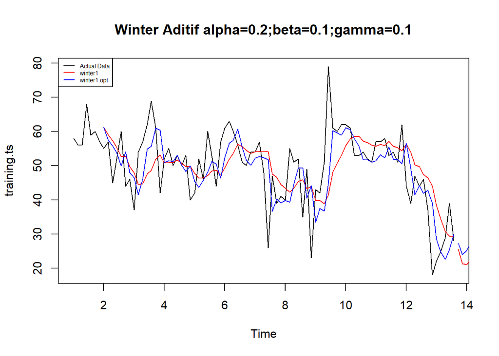

```r
plot(training.ts, main = "Winter Aditif alpha=0.2;beta=0.1;gamma=0.1", type = "l",
     col = "black")
lines(xhat1, type = "l", col = "red")
lines(xhat1.opt, type = "l", col = "blue")
lines(forecast1, type = "l", col = "red")
lines(forecast1.opt, type = "l", col = "blue")
legend("topleft", c("Actual Data", "winter1", "winter1.opt"), cex = 0.5,
       col = c("black", "red", "blue"), lty = 1)
```

Garis pemulusan (baik winter1 maupun winter1.opt) mengikuti pola naik-turun mingguan data aktual dengan cukup baik pada data latih.

#### Akurasi Data Latih

```r
SSE1  <- winter1$SSE
MSE1  <- winter1$SSE / length(training.ts)
RMSE1 <- sqrt(MSE1)

SSE1.opt  <- winter1.opt$SSE
MSE1.opt  <- winter1.opt$SSE / length(training.ts)
RMSE1.opt <- sqrt(MSE1.opt)

akurasi_winter1_train <- data.frame(
  Model_Winter = c("Winter1", "Winter1 optimal"),
  Nilai_SSE = c(SSE1, SSE1.opt),
  Nilai_MSE = c(MSE1, MSE1.opt),
  Nilai_RMSE = c(RMSE1, RMSE1.opt)
)
akurasi_winter1_train
```

```
##      Model_Winter Nilai_SSE Nilai_MSE Nilai_RMSE
## 1         Winter1  8655.982  97.25823   9.861959
## 2 Winter1 optimal  7401.877  83.16716   9.119603
```

Pada data latih, Winter1 optimal (RMSE 9,12) sedikit lebih baik dibanding Winter1 dengan parameter manual alpha=0,2;beta=0,1;gamma=0,1 (RMSE 9,86).

#### Akurasi Data Uji

```r
forecast1     <- data.frame(forecast1)
testing.ts_df <- data.frame(testing.ts)
selisih1      <- forecast1 - testing.ts_df
SSEtesting1   <- sum(selisih1^2)
MSEtesting1   <- SSEtesting1 / length(testing.ts_df)

forecast1.opt <- data.frame(forecast1.opt)
selisih1.opt  <- forecast1.opt - testing.ts_df
SSEtesting1.opt <- sum(selisih1.opt^2)
MSEtesting1.opt <- SSEtesting1.opt / length(testing.ts_df)

akurasi_testing_winter1 <- data.frame(
  Model = c("Winter1", "Winter1 Optimal"),
  SSE   = c(SSEtesting1, SSEtesting1.opt),
  MSE   = c(MSEtesting1, MSEtesting1.opt)
)
akurasi_testing_winter1
```

```
##             Model       SSE       MSE
## 1         Winter1 11916.550 11916.550
## 2 Winter1 Optimal  3263.923  3263.923
```

### Winter Multiplikatif

Perhitungan dengan model multiplikatif dilakukan jika plot data asli menunjukkan fluktuasi musiman yang meningkat/menurun seiring waktu.

#### Pemulusan

```r
winter2 <- HoltWinters(training.ts, alpha = 0.2, beta = 0.1, gamma = 0.1, seasonal = "multiplicative")
winter2$fitted
```

```
## Time Series:
## Start = c(2, 1)
## End = c(13, 5)
## Frequency = 7
##               xhat    level         trend    season
##  2.000000 60.22614 61.27041 -1.1632653061 1.0019797
##  2.142857 59.86118 59.06398 -1.2675815672 1.0357252
##  2.285714 47.70273 57.24390 -1.3228314470 0.8530368
##  2.428571 58.42808 55.28740 -1.3861986844 1.0839848
##  2.571429 51.56146 52.71519 -1.5047995635 1.0068555
##  2.714286 52.65442 52.88660 -1.3371779862 1.0214357
##  2.857143 48.20233 49.85487 -1.5066340317 0.9969823
##  3.000000 46.11926 47.90643 -1.5508140169 0.9949011
##  3.142857 44.14581 44.52242 -1.7341338767 1.0317266
##  3.285714 36.64438 44.69852 -1.5431106270 0.8491260
##  3.428571 50.36658 47.94990 -1.0636618377 1.0742296
##  3.571429 49.15087 49.05214 -0.8470708971 1.0196203
##  3.714286 52.03058 52.09851 -0.4577273026 1.0075483
##  3.857143 52.78574 53.42123 -0.2796828158 0.9933046
##  4.000000 49.38860 50.96985 -0.4968516355 0.9785152
##  4.142857 53.05924 51.00675 -0.4434769140 1.0493633
##  4.285714 44.61948 50.93317 -0.4064876886 0.8830875
##  4.428571 56.25689 51.74525 -0.2846306063 1.0932027
##  4.571429 53.05162 50.86477 -0.3442149643 1.0500997
##  4.714286 50.57632 49.93935 -0.4023355896 1.0209803
##  4.857143 48.48383 50.01179 -0.3548580304 0.9763758
##  5.000000 46.56640 47.91911 -0.5286400878 0.9826110
##  5.142857 48.24197 46.46103 -0.6215843118 1.0524116
##  5.285714 41.00776 46.55362 -0.5501667736 0.8914060
##  5.428571 50.79744 47.12354 -0.4381584507 1.0880803
##  5.571429 50.28291 48.37690 -0.2690063212 1.0452111
##  5.714286 49.61415 48.62781 -0.2170150844 1.0248572
##  5.857143 45.21303 47.31520 -0.3265747839 0.9622122
##  6.000000 48.11067 49.43860 -0.0815773905 0.9747482
##  6.142857 55.25664 52.00167  0.1828875047 1.0588696
##  6.285714 48.57223 53.64713  0.3291446294 0.8998811
##  6.428571 62.99750 56.51611  0.5831286837 1.1032984
##  6.571429 59.08346 55.83077  0.4562817470 1.0496811
##  6.714286 55.89497 54.74688  0.3022643456 1.0153649
##  6.857143 53.06217 53.88799  0.1861491015 0.9812855
```

[output cut: 32 more lines]

```
## 11.571429 57.19325 55.77532  0.2095675672 1.0215837
## 11.714286 55.91612 55.35973  0.1470519036 1.0073746
## 11.857143 51.84716 54.53075  0.0494492275 0.9499260
## 12.000000 57.26265 56.71781  0.2632099271 1.0049425
## 12.142857 58.41311 54.34154 -0.0007384665 1.0749402
## 12.285714 48.47191 50.72886 -0.3619326982 0.9623758
## 12.428571 53.35087 50.06103 -0.3925217759 1.0741388
## 12.571429 48.16446 47.92742 -0.5666309921 1.0169692
## 12.714286 46.33344 46.93512 -0.6091979069 1.0001624
## 12.857143 42.10257 44.45954 -0.7958364501 0.9642465
## 13.000000 36.82376 38.66444 -1.2957619270 0.9854176
## 13.142857 34.21569 34.36006 -1.5966243578 1.0443255
## 13.285714 28.05709 30.99853 -1.7731151118 0.9600236
## 13.428571 29.28782 29.42185 -1.7534715380 1.0585304
## 13.571429 28.30439 29.50341 -1.5699683548 1.0132799
```

```r
xhat2 <- winter2$fitted[, 2]

winter2.opt <- HoltWinters(training.ts, seasonal = "multiplicative")
winter2.opt
```

```
## Holt-Winters exponential smoothing with trend and multiplicative seasonal component.
##
## Call:
## HoltWinters(x = training.ts, seasonal = "multiplicative")
##
## Smoothing parameters:
##  alpha: 0.4837522
##  beta : 0.004915082
##  gamma: 0.1199916
##
## Coefficients:
##          [,1]
## a  28.8729524
## b  -0.9151568
## s1  1.0017764
## s2  0.9354061
## s3  0.9928067
## s4  1.0658892
## s5  0.9756736
## s6  1.0710949
## s7  1.0161004
```

```r
winter2.opt$fitted
```

```
## Time Series:
## Start = c(2, 1)
## End = c(13, 5)
## Frequency = 7
##               xhat    level      trend    season
##  2.000000 60.22614 61.27041 -1.1632653 1.0019797
##  2.142857 58.42351 57.58398 -1.1756668 1.0357252
##  2.285714 46.54553 55.74344 -1.1789348 0.8530368
##  2.428571 56.91441 53.68804 -1.1832426 1.0839848
##  2.571429 49.45435 50.31164 -1.1940222 1.0068555
##  2.714286 54.15166 54.18437 -1.1691187 1.0214357
##  2.857143 46.87279 48.20742 -1.1927496 0.9969823
##  3.000000 45.23100 46.59117 -1.1948311 0.9963578
##  3.142857 41.55762 41.40002 -1.2144733 1.0341433
##  3.285714 38.15318 46.00586 -1.1858661 0.8512536
##  3.428571 58.63646 55.53030 -1.1332240 1.0779340
##  3.571429 55.81675 55.90656 -1.1258048 1.0189117
##  3.714286 60.44777 61.03981 -1.0950410 1.0083910
##  3.857143 58.86896 60.20969 -1.0937389 0.9958219
##  4.000000 48.99280 50.92132 -1.1340162 0.9840420
##  4.142857 52.69078 51.26563 -1.1267501 1.0508965
##  4.285714 43.68397 51.20187 -1.1215254 0.8722776
##  4.428571 56.76428 53.58312 -1.1043090 1.0816608
##  4.571429 51.28701 50.79531 -1.1125835 1.0322905
##  4.714286 48.39378 49.07961 -1.1155479 1.0089592
##  4.857143 47.85592 50.17255 -1.1046930 0.9753009
##  5.000000 43.50459 45.17129 -1.1238449 0.9876757
##  5.142857 44.44787 43.31051 -1.1274670 1.0536903
##  5.285714 39.17631 45.65025 -1.1104254 0.8795794
##  5.428571 50.83852 48.29273 -1.0919796 1.0770703
##  5.571429 51.78453 51.31551 -1.0717552 1.0306661
##  5.714286 50.47387 50.81424 -1.0689512 1.0146462
##  5.857143 43.95799 46.65875 -1.0841218 0.9645278
##  6.000000 50.32457 52.11575 -1.0519717 0.9855237
##  6.142857 58.81204 56.30390 -1.0262160 1.0639382
##  6.285714 49.89319 57.18187 -1.0168568 0.8883322
##  6.428571 66.02661 61.66880 -0.9898053 1.0881295
##  6.571429 56.98461 56.22145 -1.0117145 1.0321479
##  6.714286 51.69025 52.40484 -1.0255008 1.0060513
##  6.857143 48.54782 50.56659 -1.0294955 0.9800297
```

[output cut: 32 more lines]

```
## 11.571429 53.01776 52.97939 -0.8624108 1.0172838
## 11.714286 52.41735 52.58407 -0.8601150 1.0134057
## 11.857143 48.35208 51.04738 -0.8634404 0.9634972
## 12.000000 57.63141 57.03628 -0.8297606 1.0253510
## 12.142857 53.24224 49.77533 -0.8613704 1.0884877
## 12.285714 39.55787 42.58434 -0.8924810 0.9488154
## 12.428571 46.87301 45.48621 -0.8738314 1.0506728
## 12.571429 43.19132 43.28958 -0.8803331 1.0184409
## 12.714286 43.37055 43.74336 -0.8737759 1.0116858
## 12.857143 38.09055 39.82341 -0.8887480 0.9783198
## 13.000000 28.29822 29.00044 -0.9375756 1.0083868
## 13.142857 25.72151 25.04143 -0.9524262 1.0677702
## 13.285714 21.87182 23.76212 -0.9540328 0.9589504
## 13.428571 26.65342 26.40397 -0.9363588 1.0465616
## 13.571429 30.94478 31.17457 -0.9083086 1.0224183
```

```r
xhat2.opt <- winter2.opt$fitted[, 2]
```

#### Peramalan

```r
forecast2     <- predict(winter2, n.ahead = n_test)
forecast2.opt <- predict(winter2.opt, n.ahead = n_test)
```

#### Plot Deret Waktu

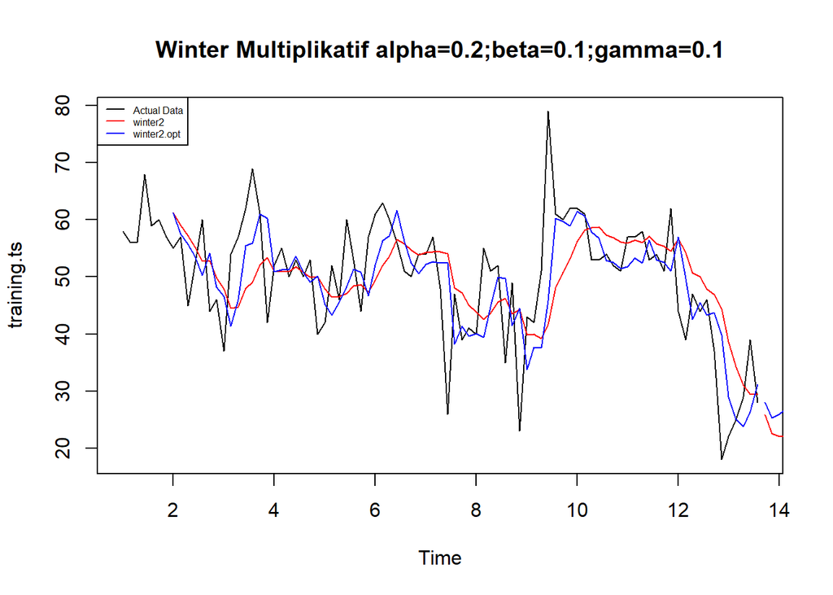

```r
plot(training.ts, main = "Winter Multiplikatif alpha=0.2;beta=0.1;gamma=0.1", type = "l",
     col = "black")
lines(xhat2, type = "l", col = "red")
lines(xhat2.opt, type = "l", col = "blue")
lines(forecast2, type = "l", col = "red")
lines(forecast2.opt, type = "l", col = "blue")
legend("topleft", c("Actual Data", "winter2", "winter2.opt"), cex = 0.5,
       col = c("black", "red", "blue"), lty = 1)
```

#### Akurasi Data Latih

```r
SSE2  <- winter2$SSE
MSE2  <- winter2$SSE / length(training.ts)
RMSE2 <- sqrt(MSE2)

SSE2.opt  <- winter2.opt$SSE
MSE2.opt  <- winter2.opt$SSE / length(training.ts)
RMSE2.opt <- sqrt(MSE2.opt)

akurasi_winter2_train <- data.frame(
  Model_Winter = c("Winter2", "Winter2 optimal"),
  Nilai_SSE = c(SSE2, SSE2.opt),
  Nilai_MSE = c(MSE2, MSE2.opt),
  Nilai_RMSE = c(RMSE2, RMSE2.opt)
)
akurasi_winter2_train
```

```
##      Model_Winter Nilai_SSE Nilai_MSE Nilai_RMSE
## 1         Winter2  8748.332  98.29587   9.914427
## 2 Winter2 optimal  7401.655  83.16466   9.119466
```

Sama seperti model aditif, pada data latih Winter2 optimal (RMSE 9,12) sedikit lebih baik dibanding Winter2 manual (RMSE 9,91). Nilai RMSE keduanya juga hampir identik dengan model Winter aditif, menandakan kedua tipe musiman ini sama-sama mampu menangkap pola data latih dengan baik.

#### Akurasi Data Uji

```r
forecast2      <- data.frame(forecast2)
selisih2       <- forecast2 - testing.ts_df
SSEtesting2    <- sum(selisih2^2)
MSEtesting2    <- SSEtesting2 / length(testing.ts_df)

forecast2.opt  <- data.frame(forecast2.opt)
selisih2.opt   <- forecast2.opt - testing.ts_df
SSEtesting2.opt <- sum(selisih2.opt^2)
MSEtesting2.opt <- SSEtesting2.opt / length(testing.ts_df)

akurasi_testing_winter2 <- data.frame(
  Model = c("Winter2", "Winter2 Optimal"),
  SSE   = c(SSEtesting2, SSEtesting2.opt),
  MSE   = c(MSEtesting2, MSEtesting2.opt)
)
akurasi_testing_winter2
```

```
##             Model       SSE       MSE
## 1         Winter2 11337.689 11337.689
## 2 Winter2 Optimal  3780.201  3780.201
```

Pada data uji, Winter2 optimal juga jauh lebih baik (SSE 3780,20) dibanding Winter2 manual (SSE 11337,69), sejalan dengan hasil pada model Winter aditif. Namun, dibandingkan **Winter1 optimal (aditif)** yang SSE data ujinya 3263,92, **Winter2 optimal (multiplikatif)** dengan SSE 3780,20 sedikit lebih besar. Artinya, untuk data PM10 ini, **model Winter Aditif optimal sedikit lebih unggul** dibanding Winter Multiplikatif optimal — sesuai dugaan awal bahwa fluktuasi musiman datanya relatif stabil (bukan berskala proporsional terhadap level data), sehingga model aditif lebih cocok.

## Kesimpulan

**1. SMA vs DMA:** SMA (MAPE data uji 22,58%) jauh lebih baik dibanding DMA (MAPE data uji 125,43%), walaupun DMA lebih unggul di data latih. DMA gagal digeneralisasi karena mengekstrapolasi tren linear dari akhir data latih yang sedang menurun tajam, sehingga hasil ramalannya menyimpang jauh dari data aktual pada periode uji.

**2. SES vs DES:** SES (alpha optimum) jelas lebih baik dibanding DES (optimum), baik pada data latih (MSE 77,09 vs 80,79) maupun data uji (MSE 46,08 vs 89,39). Ini karena data PM10 tidak memiliki tren yang konsisten, sehingga komponen tren yang dipaksakan oleh DES justru menyesatkan arah peramalan (di beberapa kombinasi parameter bahkan menghasilkan nilai ramalan negatif yang tidak masuk akal).

**3. Winter Aditif vs Winter Multiplikatif:** Kedua model musiman menghasilkan performa yang mirip pada data latih, tetapi pada data uji Winter Aditif optimal (SSE 3263,92) sedikit lebih unggul dibanding Winter Multiplikatif optimal (SSE 3780,20). Ini konsisten dengan pola musiman PM10 yang fluktuasinya relatif stabil, bukan proporsional terhadap level datanya.

**4. Metode terbaik secara keseluruhan:** Berdasarkan nilai SSE/MSE data uji, **metode Single Moving Average (SMA, m=4)** dan **Single Exponential Smoothing (SES, alpha optimum ≈ 0,508)** memberikan hasil peramalan yang **paling akurat** untuk data PM10 stasiun DKI1 (Bunderan HI), dengan SSE data uji masing-masing 1026,44 dan 1059,85 — jauh lebih kecil dibanding metode lain yang melibatkan tren (DMA, DES) maupun musiman (Winter Aditif/Multiplikatif). Alasannya, data PM10 harian pada periode ini cenderung berpola **stasioner/fluktuatif di sekitar suatu level** tanpa tren maupun musiman yang kuat dan konsisten, sehingga metode sederhana yang hanya memodelkan level data (SMA dan SES) justru lebih robust dan tidak “tertipu” oleh pergerakan tren atau musiman jangka pendek yang sebenarnya bersifat sementara/noise. Di antara keduanya, **SES (alpha optimum) sedikit lebih direkomendasikan** karena secara teori lebih adaptif (memberi bobot eksponensial menurun pada data historis) dan RMSE data ujinya (6,79) juga sudah cukup rendah dibandingkan skala data PM10 (rata-rata 45,64).